# Group12-Project3

Ganghyun Kim(01715699),Seungchan Oh(01603277), Wonjong Bum(01815150)

2022 5 21

## 1. Read in the given dataset and make a plot of the oxygen uptake rate with respect to time.

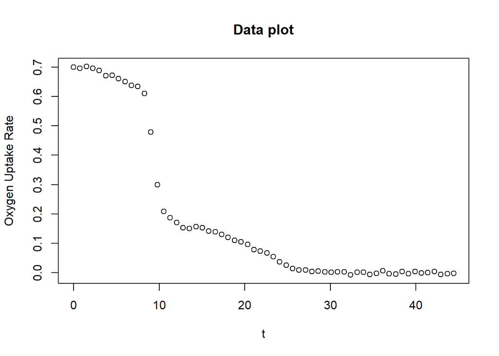

```r
plot(our.data ~ our.times, main = "Data plot", xlab='t', ylab='Oxygen Uptake Rate')
```

## 2. Perform a parameter estimation for the single and double Monod models, using the following initial parameter estimates. Report the optimized parameter values.

#### For **single** Monod:

> $\alpha = 0.5,\ \beta = 2.7,\ S(0) = 2.0$

#### For **double** Monod:

> $\alpha_1 = -1.20,\ \beta_1 = 0.34,\ S_1(0) = 1.39,\\ \alpha_2 = -0.69,\ \beta_2 = -1.61,\ S_2(0) = 0.34$

```r
# alpha, beta, S parameter
singlePar <- c(0.5, 2.7, 2.0) # Single
doublePar1 <- c(-1.20, 0.34,  1.39) # Double 1
doublePar2 <- c(-0.69, -1.61, 0.34) # Double 2

# Objective function
Jobjective <- function(thetas, FUN, xdata, ydata) {
  y_est <- do.call(FUN, list(xdata, thetas))
  y_resid <- ydata - y_est
  J <- sum(y_resid^2)
  return(J)
}

# Optimization of models
singlefit <- optim(par = singlePar, fn = Jobjective, FUN = single.monod, xdata = our.times, ydata = our.data)
doublefit <- optim(par = c(doublePar1, doublePar2), fn = Jobjective, FUN = double.monod, xdata = our.times, ydata = our.data)
```

The optimized set of parameters for the single Monod model is,

```r
singlefit$par
```

```
## [1] 0.1055487 1.2173668 2.0539967
```

The optimized set of parameters for the double Monod model is,

```r
doublefit$par
```

```
## [1] -0.9441961  0.5337438  1.4893810 -0.8215955 -2.3312929  1.3435334
```